# index

### Patrick Mugisha, "On my honor, as a student, I have neither given nor received unauthorized aid on this academic work."

```python
#import python packages
import pandas as pd
import numpy as np
import matplotlib.pyplot as plt
%matplotlib inline
import seaborn as sns
import warnings
warnings.filterwarnings("ignore", category=FutureWarning)
pd.set_option('display.max_columns', None)

print(sns.__version__)    #check seaborn version
```

```
0.11.0
```

```python
df=pd.read_csv("data/bank.csv")
df.head()
```

|  | CHK_ACCT | DURATION | HISTORY | NEW_CAR | USED_CAR | FURNITURE | RADIO/TV | EDUCATION | RETRAINING | AMOUNT | SAV_ACCT | EMPLOYMENT | INSTALL_RATE | MALE_DIV | MALE_SINGLE | MALE_MAR_or_WID | CO-APPLICANT | GUARANTOR | PRESENT_RESIDENT | REAL_ESTATE | PROP_UNKN_NONE | AGE | OTHER_INSTALL | RENT | OWN_RES | NUM_CREDITS | JOB | NUM_DEPENDENTS | TELEPHONE | … |
| --- | --- | --- | --- | --- | --- | --- | --- | --- | --- | --- | --- | --- | --- | --- | --- | --- | --- | --- | --- | --- | --- | --- | --- | --- | --- | --- | --- | --- | --- | --- |
| 0 | 0 | 6 | 4 | 0 | 0 | 0 | 1 | 0 | 0 | 1169 | 4 | 4 | 4 | 0 | 1 | 0 | 0 | 0 | 4 | 1 | 0 | 67 | 0 | 0 | 1 | 2 | 2 | 1 | 1 | … |
| 1 | 1 | 48 | 2 | 0 | 0 | 0 | 1 | 0 | 0 | 5951 | 0 | 2 | 2 | 0 | 0 | 0 | 0 | 0 | 2 | 1 | 0 | 22 | 0 | 0 | 1 | 1 | 2 | 1 | 0 | … |
| 2 | 3 | 12 | 4 | 0 | 0 | 0 | 0 | 1 | 0 | 2096 | 0 | 3 | 2 | 0 | 1 | 0 | 0 | 0 | 3 | 1 | 0 | 49 | 0 | 0 | 1 | 1 | 1 | 2 | 0 | … |
| 3 | 0 | 42 | 2 | 0 | 0 | 1 | 0 | 0 | 0 | 7882 | 0 | 3 | 2 | 0 | 1 | 0 | 0 | 1 | 4 | 0 | 0 | 45 | 0 | 0 | 0 | 1 | 2 | 2 | 0 | … |
| 4 | 0 | 24 | 3 | 1 | 0 | 0 | 0 | 0 | 0 | 4870 | 0 | 2 | 3 | 0 | 1 | 0 | 0 | 0 | 4 | 0 | 1 | 53 | 0 | 0 | 0 | 2 | 2 | 2 | 0 | … |

### Q1. Use some common sense (and/or your business knowledge) to answer the first question. Which columns or (independent) variables would significantly influence the Y value (whether someone fulfills the terms of credit agreement or not)? List at least three and explain why?

#### Name the column (variable) and explain why?

- AGE will influence Y value because if the person is too old they might die before they finish paying up their loan, and if the person is too young they might be careless because they don't have enough financial literacy.

#### Name the column (variable) and explain why?

- EMPLOYMENT will influence Y value because it provides information of where the funds are going to come from when paying back your loans.

#### Name the column (variable) and explain why?

- REAL_ESTATE will influence Y value because the bank will have something to hold as collateral if for any reason you will be unable to pay back your loan

## Q2. What are some general findings from basic statistics (describe)?

```python
df.describe()
```

|  | CHK_ACCT | DURATION | HISTORY | NEW_CAR | USED_CAR | FURNITURE | RADIO/TV | EDUCATION | RETRAINING | AMOUNT | SAV_ACCT | EMPLOYMENT | INSTALL_RATE | MALE_DIV | MALE_SINGLE | MALE_MAR_or_WID | CO-APPLICANT | GUARANTOR | PRESENT_RESIDENT | REAL_ESTATE | PROP_UNKN_NONE | AGE | OTHER_INSTALL | RENT | OWN_RES | NUM_CREDITS | JOB | NUM_DEPENDENTS | TELEPHONE | … |
| --- | --- | --- | --- | --- | --- | --- | --- | --- | --- | --- | --- | --- | --- | --- | --- | --- | --- | --- | --- | --- | --- | --- | --- | --- | --- | --- | --- | --- | --- | --- |
| count | 1000.000000 | 1000.000000 | 1000.00000 | 1000.000000 | 1000.000000 | 1000.000000 | 1000.000000 | 1000.000000 | 1000.000000 | 1000.000000 | 1000.000000 | 1000.000000 | 1000.000000 | 1000.000000 | 1000.00000 | 1000.000000 | 1000.000000 | 1000.000000 | 1000.000000 | 1000.000000 | 1000.000000 | 1000.000000 | 1000.000000 | 1000.000000 | 1000.000000 | 1000.000000 | 1000.000000 | 1000.000000 | 1000.000000 | … |
| mean | 1.577000 | 20.903000 | 2.54500 | 0.234000 | 0.103000 | 0.181000 | 0.280000 | 0.050000 | 0.097000 | 3271.258000 | 1.105000 | 2.384000 | 2.973000 | 0.050000 | 0.54800 | 0.092000 | 0.041000 | 0.052000 | 2.845000 | 0.282000 | 0.154000 | 35.546000 | 0.186000 | 0.179000 | 0.713000 | 1.407000 | 1.904000 | 1.155000 | 0.404000 | … |
| std | 1.257638 | 12.058814 | 1.08312 | 0.423584 | 0.304111 | 0.385211 | 0.449224 | 0.218054 | 0.296106 | 2822.736876 | 1.580023 | 1.208306 | 1.118715 | 0.218054 | 0.49794 | 0.289171 | 0.198389 | 0.222138 | 1.103718 | 0.450198 | 0.361129 | 11.375469 | 0.389301 | 0.383544 | 0.452588 | 0.577654 | 0.653614 | 0.362086 | 0.490943 | … |
| min | 0.000000 | 4.000000 | 0.00000 | 0.000000 | 0.000000 | 0.000000 | 0.000000 | 0.000000 | 0.000000 | 250.000000 | 0.000000 | 0.000000 | 1.000000 | 0.000000 | 0.00000 | 0.000000 | 0.000000 | 0.000000 | 1.000000 | 0.000000 | 0.000000 | 19.000000 | 0.000000 | 0.000000 | 0.000000 | 1.000000 | 0.000000 | 1.000000 | 0.000000 | … |
| 25% | 0.000000 | 12.000000 | 2.00000 | 0.000000 | 0.000000 | 0.000000 | 0.000000 | 0.000000 | 0.000000 | 1365.500000 | 0.000000 | 2.000000 | 2.000000 | 0.000000 | 0.00000 | 0.000000 | 0.000000 | 0.000000 | 2.000000 | 0.000000 | 0.000000 | 27.000000 | 0.000000 | 0.000000 | 0.000000 | 1.000000 | 2.000000 | 1.000000 | 0.000000 | … |
| 50% | 1.000000 | 18.000000 | 2.00000 | 0.000000 | 0.000000 | 0.000000 | 0.000000 | 0.000000 | 0.000000 | 2319.500000 | 0.000000 | 2.000000 | 3.000000 | 0.000000 | 1.00000 | 0.000000 | 0.000000 | 0.000000 | 3.000000 | 0.000000 | 0.000000 | 33.000000 | 0.000000 | 0.000000 | 1.000000 | 1.000000 | 2.000000 | 1.000000 | 0.000000 | … |
| 75% | 3.000000 | 24.000000 | 4.00000 | 0.000000 | 0.000000 | 0.000000 | 1.000000 | 0.000000 | 0.000000 | 3972.250000 | 2.000000 | 4.000000 | 4.000000 | 0.000000 | 1.00000 | 0.000000 | 0.000000 | 0.000000 | 4.000000 | 1.000000 | 0.000000 | 42.000000 | 0.000000 | 0.000000 | 1.000000 | 2.000000 | 2.000000 | 1.000000 | 1.000000 | … |
| max | 3.000000 | 72.000000 | 4.00000 | 1.000000 | 1.000000 | 1.000000 | 1.000000 | 1.000000 | 1.000000 | 18424.000000 | 4.000000 | 4.000000 | 4.000000 | 1.000000 | 1.00000 | 1.000000 | 1.000000 | 1.000000 | 4.000000 | 1.000000 | 1.000000 | 75.000000 | 1.000000 | 1.000000 | 1.000000 | 4.000000 | 3.000000 | 2.000000 | 1.000000 | … |

#### What is the most popular checking account status in the data?

```python
df.sort_values('CHK_ACCT', ascending=False).head(1)
```

|  | CHK_ACCT | DURATION | HISTORY | NEW_CAR | USED_CAR | FURNITURE | RADIO/TV | EDUCATION | RETRAINING | AMOUNT | SAV_ACCT | EMPLOYMENT | INSTALL_RATE | MALE_DIV | MALE_SINGLE | MALE_MAR_or_WID | CO-APPLICANT | GUARANTOR | PRESENT_RESIDENT | REAL_ESTATE | PROP_UNKN_NONE | AGE | OTHER_INSTALL | RENT | OWN_RES | NUM_CREDITS | JOB | NUM_DEPENDENTS | TELEPHONE | … |
| --- | --- | --- | --- | --- | --- | --- | --- | --- | --- | --- | --- | --- | --- | --- | --- | --- | --- | --- | --- | --- | --- | --- | --- | --- | --- | --- | --- | --- | --- | --- |
| 898 | 3 | 15 | 2 | 0 | 0 | 1 | 0 | 0 | 0 | 2186 | 4 | 3 | 1 | 0 | 0 | 0 | 0 | 0 | 4 | 1 | 0 | 33 | 1 | 1 | 0 | 1 | 1 | 1 | 0 | … |

#### What is the maximum loan duration?

```python
df['DURATION'].max()
```

```
72
```

#### What was the minimum loan amount?

```python
df['AMOUNT'].min()
```

```
250
```

## Q3. What portion of borrowers have paid back? What portion have defaulted on their loans? You need to use a pivot table or charts. Provide a discussion of the findings in a markdown

```python
# pivot table using response
# 700 borrowers have paid back their loans and 300 borrowers have defaulted on their loans

df.groupby('RESPONSE').size()
```

```
RESPONSE
0    300
1    700
dtype: int64
```

```python
#created a dataframe for RESPONSE

payback=df.groupby('RESPONSE').size().reset_index()
payback
```

|  | RESPONSE | 0 |
| --- | --- | --- |
| 0 | 0 | 300 |
| 1 | 1 | 700 |

#### Show atleast one pie plot

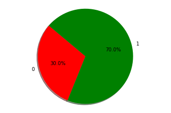

```python
# 70 percent of people who took out a loan have paid it back
# 30 percent of people who took out a loan defaulted on their loan

colors = ['red', 'green']

plt.pie(payback[0], labels=payback['RESPONSE'], colors=colors, autopct='%1.1f%%', shadow=True, startangle=140)

plt.axis('equal');
```

#### Show atleast one bar plot

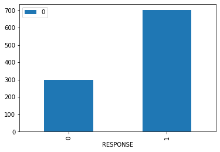

```python
payback.groupby('RESPONSE').sum().plot(kind='bar');
```

## Q4. Demonstrate your skills in groupby to extract business intelligence. The focus of your analysis should be who is likely to pay back/default on the loan. Provide

```python
df.groupby("RESPONSE").mean()
```

| RESPONSE | CHK_ACCT | DURATION | HISTORY | NEW_CAR | USED_CAR | FURNITURE | RADIO/TV | EDUCATION | RETRAINING | AMOUNT | SAV_ACCT | EMPLOYMENT | INSTALL_RATE | MALE_DIV | MALE_SINGLE | MALE_MAR_or_WID | CO-APPLICANT | GUARANTOR | PRESENT_RESIDENT | REAL_ESTATE | PROP_UNKN_NONE | AGE | OTHER_INSTALL | RENT | OWN_RES | NUM_CREDITS | JOB | NUM_DEPENDENTS | TELEPHONE | … |
| --- | --- | --- | --- | --- | --- | --- | --- | --- | --- | --- | --- | --- | --- | --- | --- | --- | --- | --- | --- | --- | --- | --- | --- | --- | --- | --- | --- | --- | --- | --- |
| 0 | 0.903333 | 24.860000 | 2.166667 | 0.296667 | 0.056667 | 0.193333 | 0.206667 | 0.073333 | 0.113333 | 3938.126667 | 0.673333 | 2.170000 | 3.096667 | 0.066667 | 0.486667 | 0.083333 | 0.060000 | 0.033333 | 2.850000 | 0.200000 | 0.223333 | 33.963333 | 0.253333 | 0.233333 | 0.620000 | 1.366667 | 1.936667 | 1.153333 | 0.376667 | … |
| 1 | 1.865714 | 19.207143 | 2.707143 | 0.207143 | 0.122857 | 0.175714 | 0.311429 | 0.040000 | 0.090000 | 2985.457143 | 1.290000 | 2.475714 | 2.920000 | 0.042857 | 0.574286 | 0.095714 | 0.032857 | 0.060000 | 2.842857 | 0.317143 | 0.124286 | 36.224286 | 0.157143 | 0.155714 | 0.752857 | 1.424286 | 1.890000 | 1.155714 | 0.415714 | … |

#### Use groupby for analysis

```python
# total number of people that asked for a loan in each category of EMPLOYMENT
client_count=df.groupby('EMPLOYMENT').size()

# total number of people that paid back their loan in each category of EMPLOYMENT according to RESPONSE
payback_sum=df.groupby('EMPLOYMENT').RESPONSE.sum()

print(client_count)
print("-----------------------------------------------------------")
print(payback_sum)
```

```
EMPLOYMENT
0     62
1    172
2    339
3    174
4    253
dtype: int64
-----------------------------------------------------------
EMPLOYMENT
0     39
1    102
2    235
3    135
4    189
Name: RESPONSE, dtype: int64
```

#### Visualize the outcomes of groupby

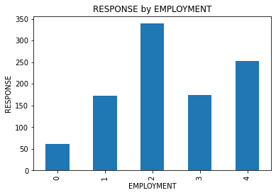

```python
client_count.plot(kind='bar')
plt.xlabel('EMPLOYMENT')
plt.ylabel('RESPONSE')
plt.title("RESPONSE by EMPLOYMENT")
```